# Resultados

O objetivo desta seção é apresentar a performance dos diversos modelos estimados por meio de medidas de acurácia, especialmente o mean absolute percentage error (MAPE).

O gráfico abaixo mostra a dispersão dos MAPEs para cada modelo. É possível notar que os modelos ARIMA, ETS e STAR tiveram o melhor desempenho (menor mediana dos MAPEs) como menos variabilidade da performance ao longo do horizonte de previsão (menor IQR).

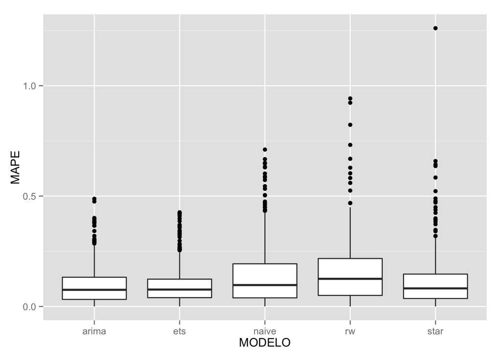

Além da performance em relação aos modelos, também é interessante a análise se algum estado possui uma série da RCL com maior previsibilidade. O gráfico abaixo mostra que os estados de Santa Catarina (mediana do MAPE de 0.0382981) e Paraná (mediana do MAPE de 0.04321) possuem os melhores resultados. Eles são até 5.1151355 mais previsiveis que AP.

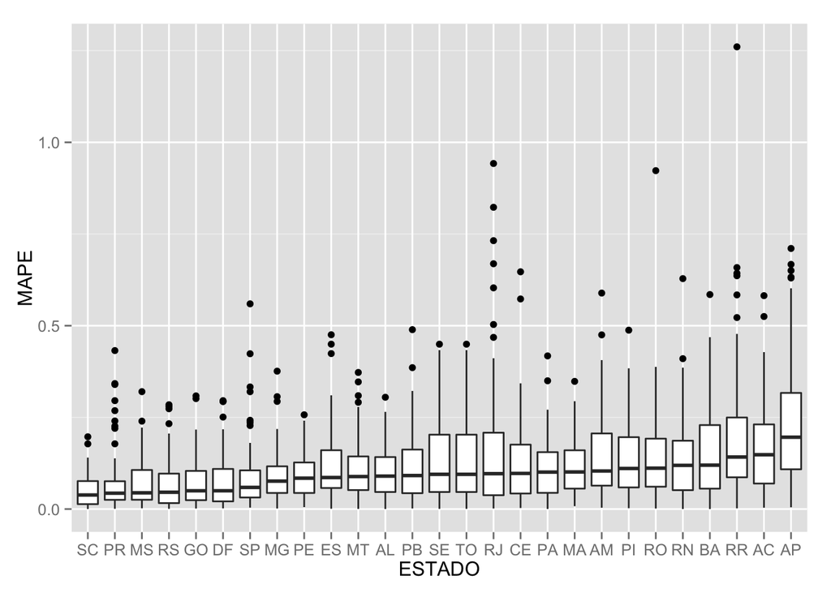